# Final Project

Author

Vijayashree Marupeddi

**Section 1**

#### Exploratory Data Analysis and Time Series Decomposition

##### Introduction

The time series data selected is Median Sales Price of US Houses Sold. The data is downloaded from FRED website but the originally it is sourced from U.S. Census Bureau and U.S. Department of Housing and Urban Development.

Median House Sales Price is present once for year quarter of the year and is available from 1963 January till 2022 July.

I chose this data particularly to analyse and forecast house prices across US in light of the recent events - COVID 19 and INFLATION. The housing market has been the sector hardest hit by aggressive Federal Reserve interest rate hikes that are aimed at curbing high inflation by dampening demand in the economy.

As a result the mortgage rates have sky rocketed and reached it’s highest level in the last 20 years. This has led to a slow down of both buying activity and purchase prices. Many economists remain mixed about whether home prices will continue to increase or decelerate.

##### Data-generating process, variation in the variable, Difficulty to forecast:

The data has been generated through data collection process from the Survey of Construction (SOC). Approximately 900 households from every locality are randomly sampled. For every building, a field representative contacts the owner or builder, by telephone or in person, to conduct the interview each month as necessary. Contact continues until the project is either completed or abandoned. If a single-family home is not sold by the time of completion, the project will continue to be followed until the sale occurs. Each month, interviews are required for about half of the buildings currently being followed up.

**Factors affecting or driving variation in the variable could be:**

- International Trade: Goods & Services
- Wholesale Inventories
- Adjustable-rate mortgages
- Days on the market
- New Residential Constructions
- Construction Spending
- Homeownership Rate
- Business Inventories

Forecasting this variable for the current time by utilizing historical data points period (in the last decade) will be quite challenging given the landscape is drastically different owing to COVID-19, geopolitical issues and thus inflation. The drivers affecting the price no longer seem to be following conventional trend/seasonality. This will in return affect the forecast of house prices.

**Trend**

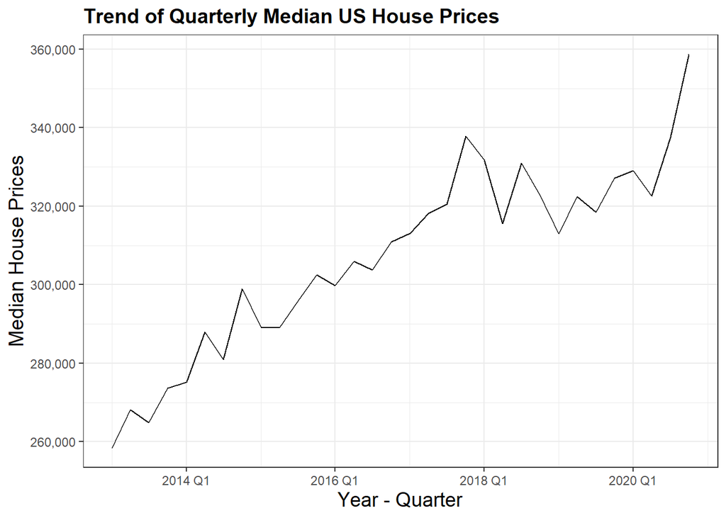

**Summary Statistics**

```
                   Count     Mean Standard Deviation    Min    Max  Range
Median House Price    32 307021.9           23892.85 258400 358700 100300
```

**Data Distribution**

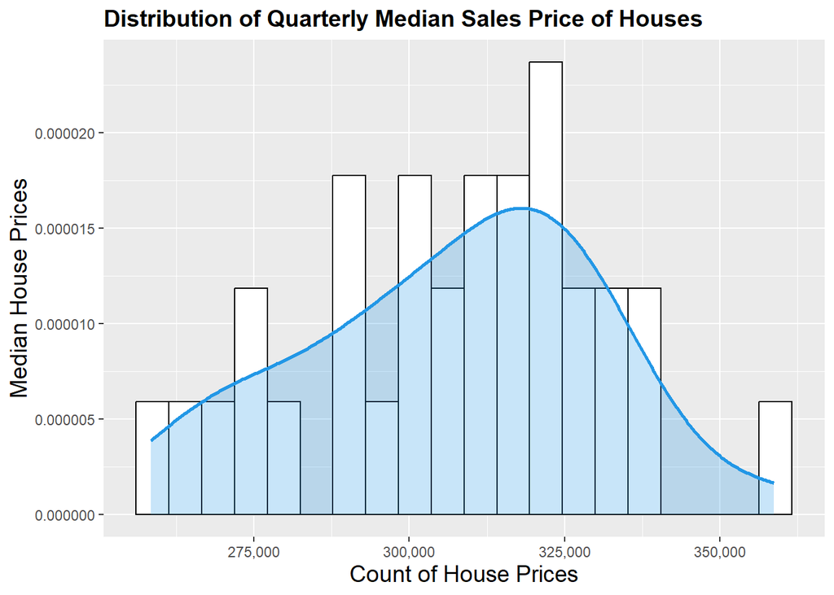

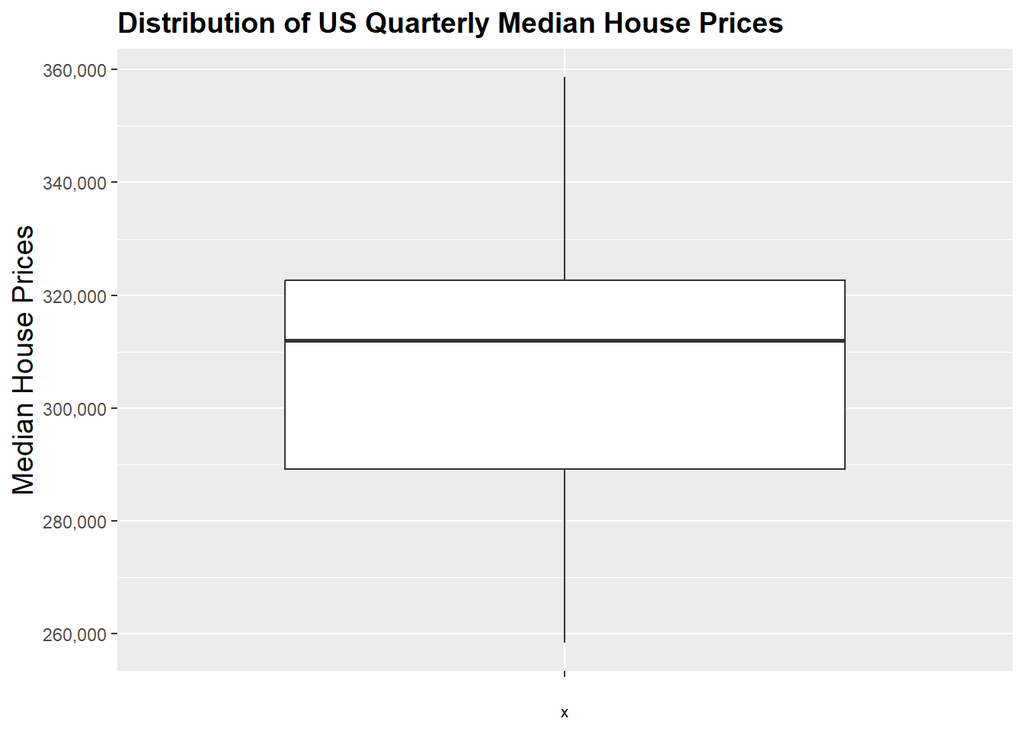

From the box plot below there aren’t any outliers

**Moving Average**

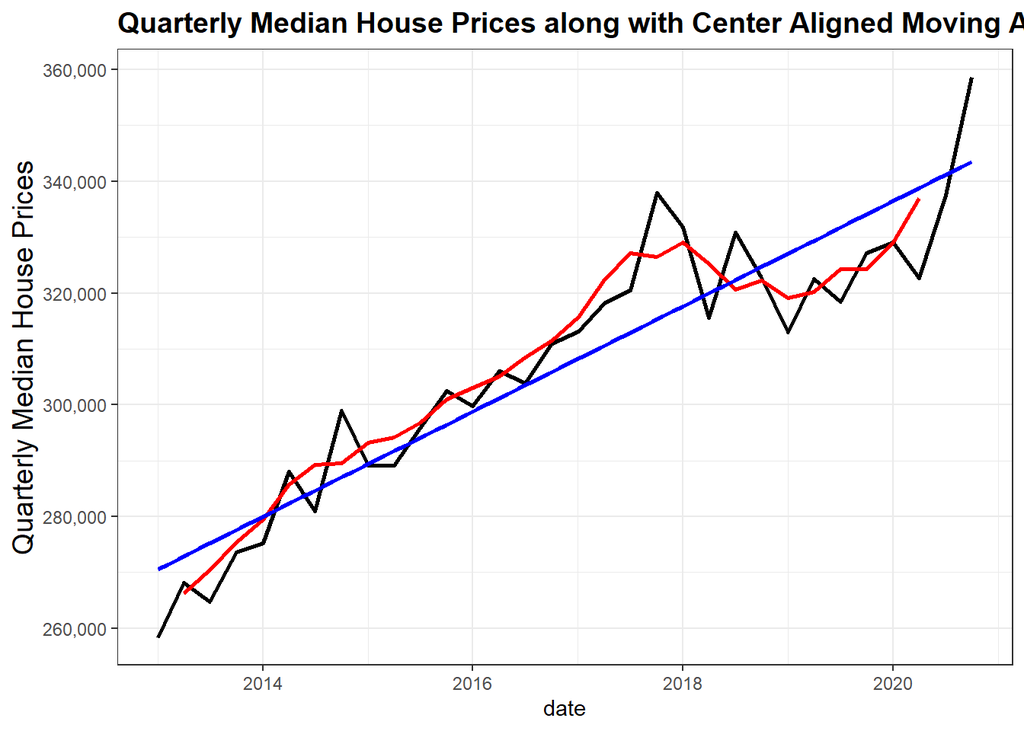

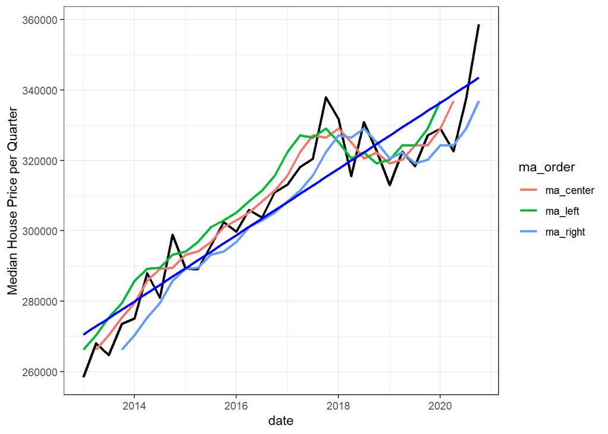

Assessment: The series doesn’t look mean stationary

**Decomposition**

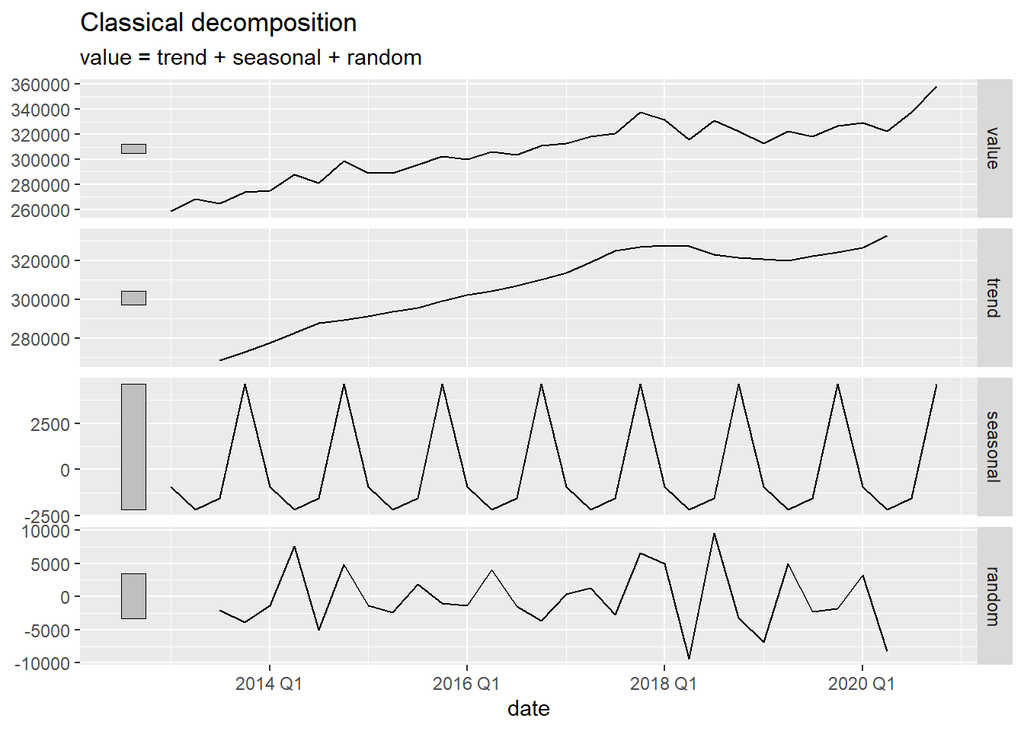

**Lag Plot** One Lag represents - One quarter.

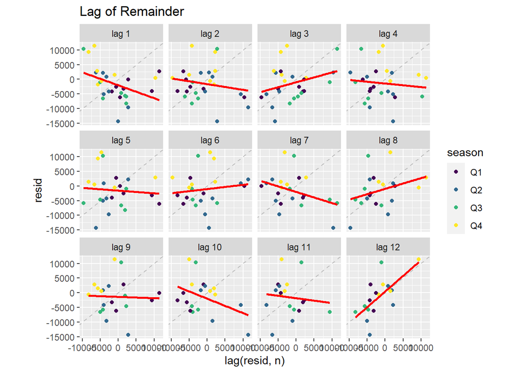

Going forward, seasonality will not be accounted for in the analysis

**Section 2**

#### ARIMA Modeling

**Stationarity**

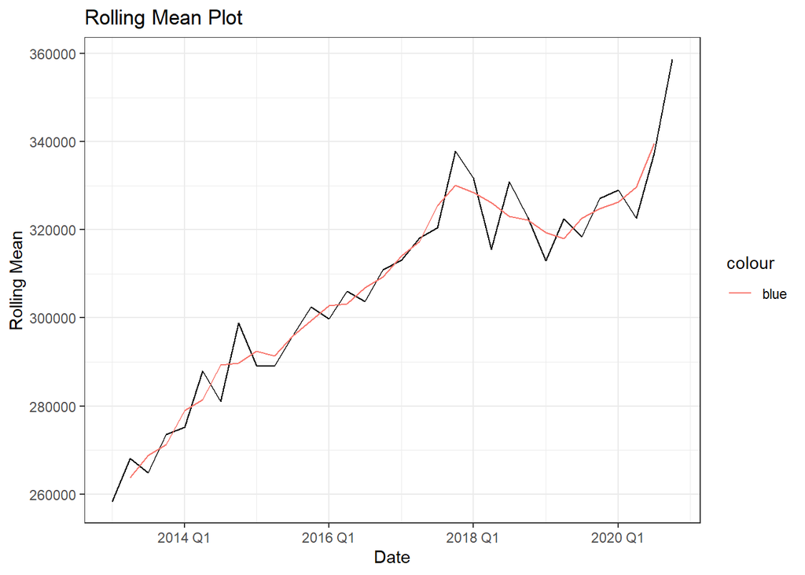

The Quarterly Median Household Sales Price is not mean stationary.

**KPSS Test**

KPSS test is a statistical test to check for stationarity of a series around a deterministic trend. The null hypothesis of the KPSS test is that the series is stationary. If p-value is < signif level (say 0.1, with 90% confidence interval), then the series is non-stationary.

```
    KPSS Test for Trend Stationarity

data:  household_SP_med_train$value
KPSS Trend = 0.14217, Truncation lag parameter = 3, p-value = 0.05708
```

```
[1] "Time series is not trend stationary"
```

**ADF Test**

```
    Augmented Dickey-Fuller Test

data:  household_SP_med_train$value
Dickey-Fuller = -3.144, Lag order = 0, p-value = 0.1315
alternative hypothesis: stationary
```

```
[1] "Data is not stationary with respect to mean"
```

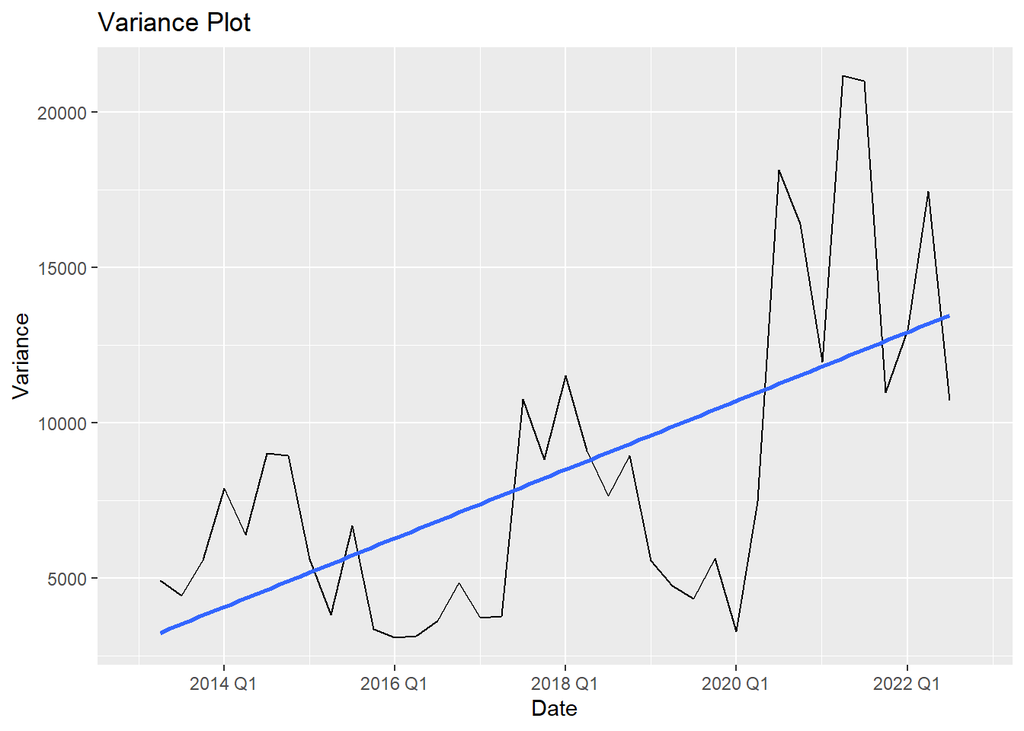

The quarterly household median sales price series is not variance stationary.

```
    Augmented Dickey-Fuller Test

data:  household_SP_med_train$value
Dickey-Fuller = -3.144, Lag order = 0, p-value = 0.1315
alternative hypothesis: stationary
```

```
[1] "Data is not stationary with respect to variance"
```

The household sales price series needs to transformed to induce both mean and variance stationary.

**Step 1** is to transform the series to make it variance stationary

**Step 2** is to transform the series to make it mean stationary

**Transformations**

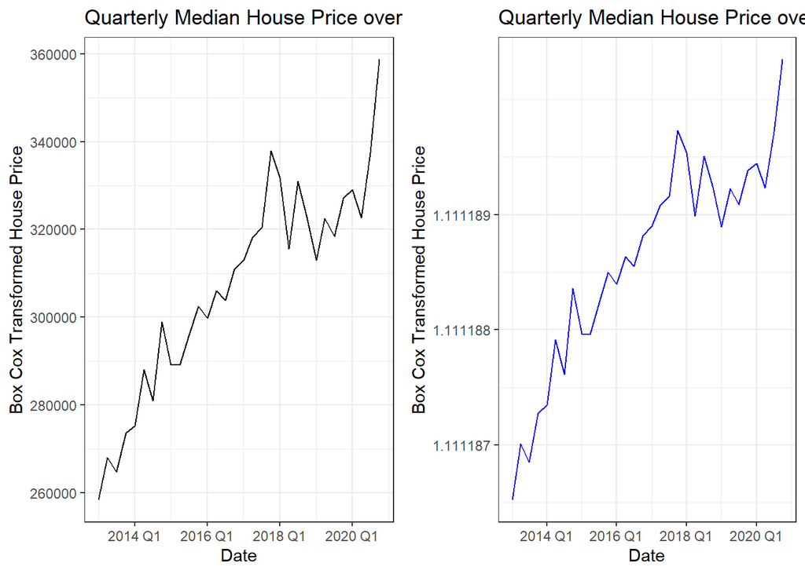

Mean stationary can be induced by differencing the transformed data :

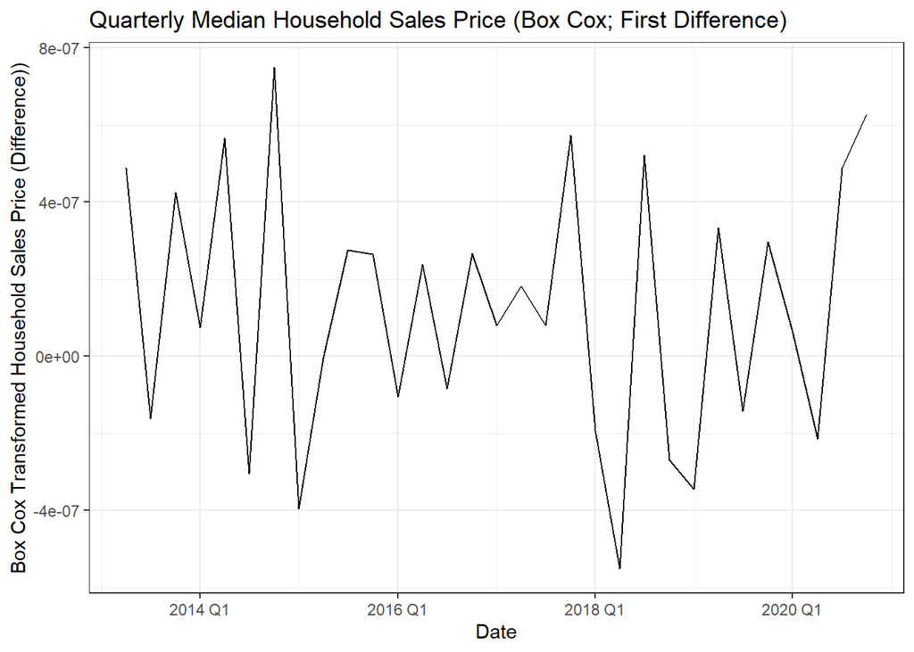

###### Checking whether the transformed series is statipnary or not using KPSS & ADF tests:

**KPSS Test**

```
    KPSS Test for Trend Stationarity

data:  household_diff$close_box_diff
KPSS Trend = 0.11128, Truncation lag parameter = 2, p-value = 0.1
```

```
[1] "Time series is trend stationary"
```

**ADF Test**

```
    Augmented Dickey-Fuller Test

data:  household_diff[-1, ]$close_box_diff
Dickey-Fuller = -7.7054, Lag order = 0, p-value = 0.01
alternative hypothesis: stationary
```

```
[1] "Data is stationary with respect to mean"
```

```
    Augmented Dickey-Fuller Test

data:  household_diff[-1, ]$close_box_diff
Dickey-Fuller = -7.7054, Lag order = 0, p-value = 0.01
alternative hypothesis: stationary
```

```
[1] "Data is stationary with respect to variance"
```

###### The household series has been transformed to induce both mean and variance stationary

**ACF-PACF**

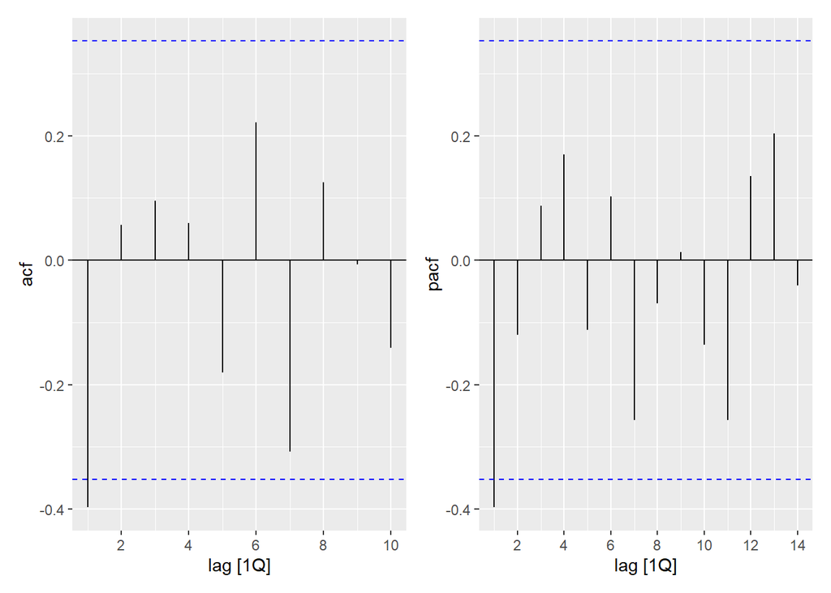

There isn’t a strong geometrically declining pattern in both ACF and PACF plots above. In both the plots, since ACF and PACF have significant lag of 1. There is no clear indication of the order of AR. However, MA order can be said that it is equal to 1.

**Model selection**

###### Building ARIMA Models

```r
models_bic = household_diff %>%
  model(
    mod1 = ARIMA(value_boxcox~pdq(0,1,0)+PDQ(0,0,0)),
    mod2 = ARIMA(value_boxcox~pdq(0,1,1)+PDQ(0,0,0)),
    mod3 = ARIMA(value_boxcox~pdq(1,1,0)+PDQ(0,0,0)),
    mod4 = ARIMA(value_boxcox~pdq(2,1,0)+PDQ(0,0,0)),
    mod5 = ARIMA(value_boxcox~pdq(2,1,1)+PDQ(0,0,0)),
    mod6 = ARIMA(value_boxcox~pdq(0,1,2)+PDQ(0,0,0))
  )

models_bic %>%
  glance() %>%
  arrange(BIC)
```

```
# A tibble: 6 × 8
  .model       sigma2 log_lik   AIC  AICc   BIC ar_roots  ma_roots
  <chr>         <dbl>   <dbl> <dbl> <dbl> <dbl> <list>    <list>
1 mod3   0.0000000441    408. -809. -808. -805. <cpl [1]> <cpl [0]>
2 mod2   0.0000000441    407. -809. -808. -804. <cpl [0]> <cpl [1]>
3 mod1   0.0000000426    405. -806. -805. -803. <cpl [0]> <cpl [0]>
4 mod6   0.0000000457    408. -808. -806. -802. <cpl [0]> <cpl [2]>
5 mod4   0.0000000457    408. -807. -806. -802. <cpl [2]> <cpl [0]>
6 mod5   0.0000000475    408. -805. -803. -798. <cpl [2]> <cpl [1]>
```

Model 3 = ARIMA(1,1,0) is the best model according to BIC (having the lowest BIC)

**Checking with Auto ARIMA**:

```
Series: value_boxcox
Model: ARIMA(1,1,0) w/ drift

Coefficients:
          ar1  constant
      -0.3398         0
s.e.      NaN       NaN

sigma^2 estimated as 4.41e-08:  log likelihood=407.55
AIC=-809.1   AICc=-808.18   BIC=-804.9
```

Auto arima using BIC gives the same model 3 as the result: ARIMA(1,1,0)

**Residual Diagnostics**

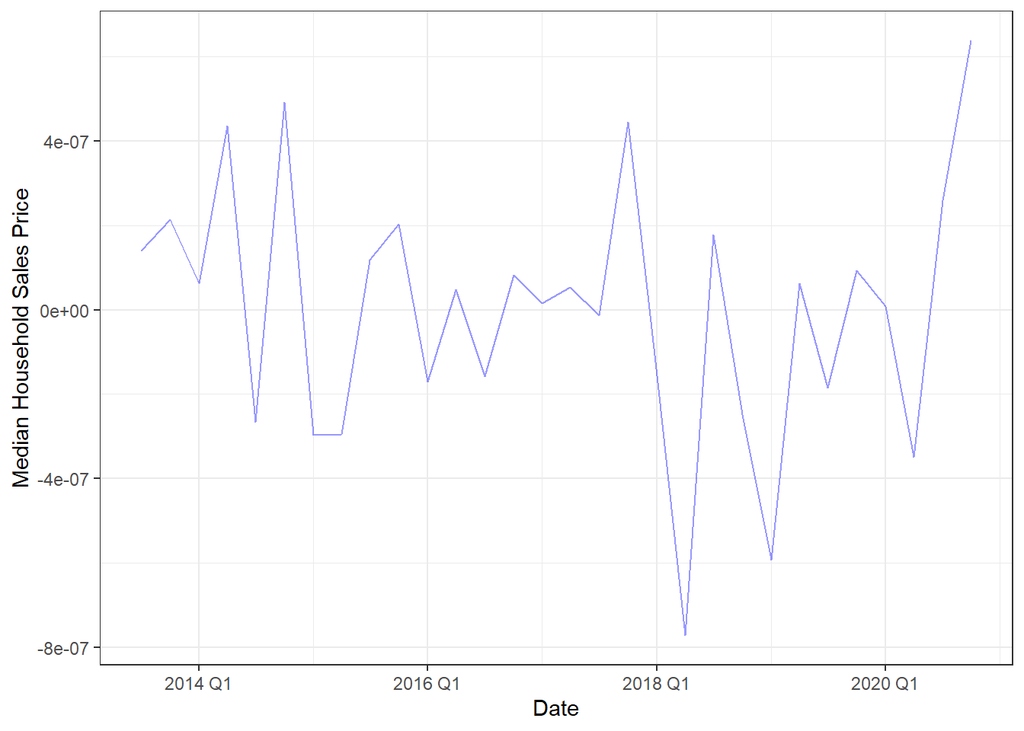

Residuals look like white noise. Hence there is nor AR or seasonality left in the remainder

**Plot diagnosis of residuals**

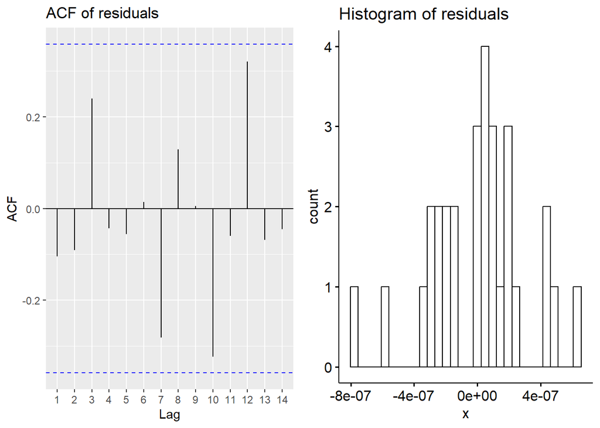

There isn’t any autocorrelation left in residuals. This can been inferred from ACF plot. The residual ACF suggests that there is not any significant seasonality left.

The histogram is normally distributed (almost!) and nean is centered around zero.

A normal distribution of residuals indicates that the model is accurately capturing the underlying patterns in the data, and the residuals are randomly distributed around zero with a constant variance. A normal distribution of residuals is indicative of a well-specified model, while non-normal distributions may indicate a need for model improvement or further investigation.

**Box-Ljung test**

```r
lag5 <- best_mod %>%
        augment() %>%
        features(.innov, ljung_box, lag = 3, dof = 1)

if(lag5$lb_pvalue< 0.05){
  print("residual autocorrelation present at Lag 3")
} else {
  print("residual autocorrelation not present at Lag 3")
}
```

```
[1] "residual autocorrelation not present at Lag 3"
```

```r
lag1 <- best_mod %>%
        augment() %>%
        features(.innov, ljung_box, lag = 7, dof = 1)

if(lag1$lb_pvalue < 0.05){
  print("residual autocorrelation present at Lag 7")
} else {
  print("residual autocorrelation not present at Lag 7")
}
```

```
[1] "residual autocorrelation not present at Lag 7"
```

The Box-Ljung test suggests no autocorrelation left in the residuals

**Section 3**

#### Meta Prophet Model

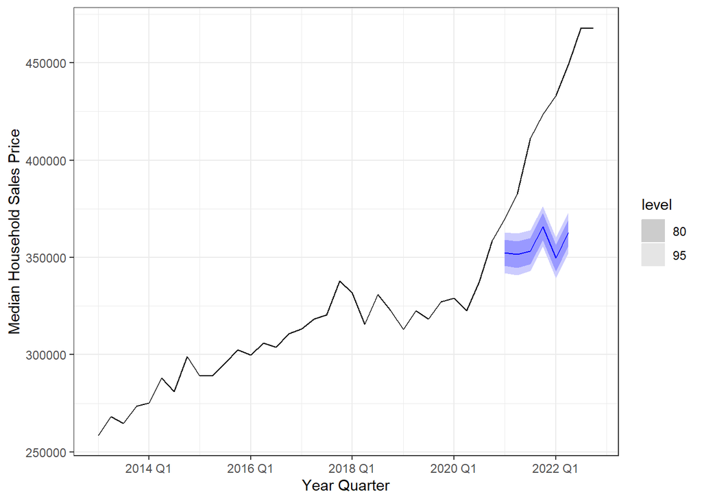

```r
library(fable.prophet)

fit <- household_SP_med_train %>%
#filter(date<=ymd('2019-01-01')) %>%
    model(prophet = fable.prophet::prophet(value))

fit %>% forecast(h=6) %>%
    autoplot(household_SP_med_train %>% bind_rows(household_SP_med_test))+
    ylab('Median Household Sales Price')+
    xlab('Year Quarter')+
    theme_bw()
```

Initial Model’s forecast doesn’t look good. It is not in alignment with the recent trend. The actuals are off because of Covid period.

**Visualizing the Components**

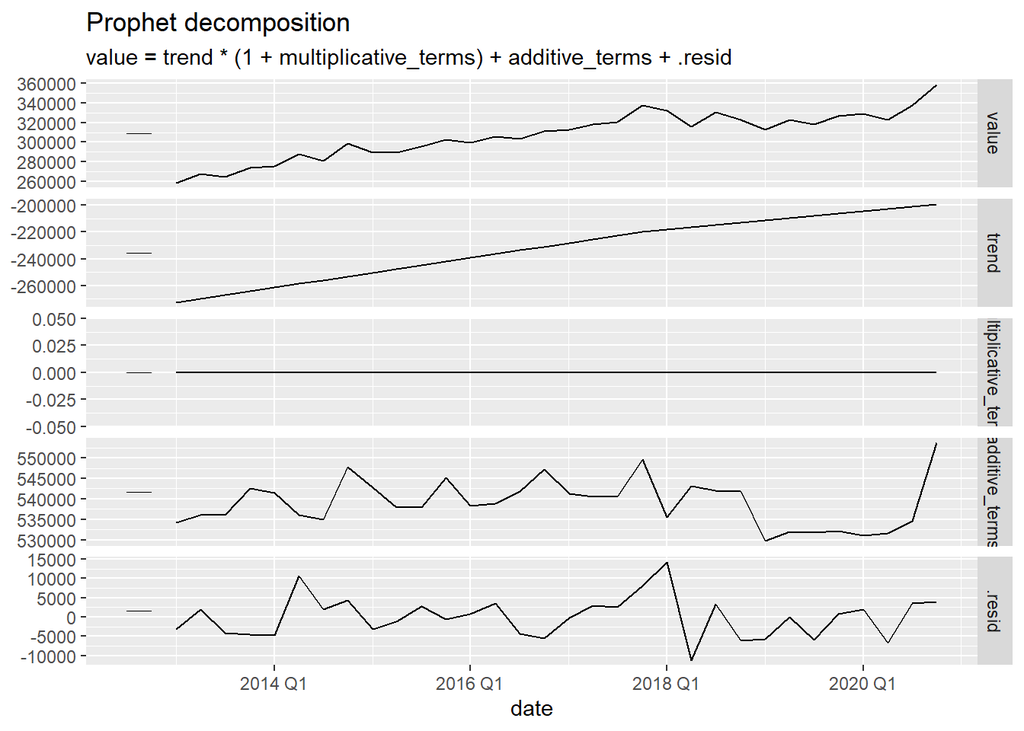

```r
household_SP_decomp <- fit %>% components()

household_SP_decomp |> autoplot()
```

Multiplicative term is completely missing. Hence, there isn’t any significant presence of multiplicative seasonality as well.

The trend component suggests a linear increase in the data

**Changepoints**

**Automatic Change Points detected by the model**

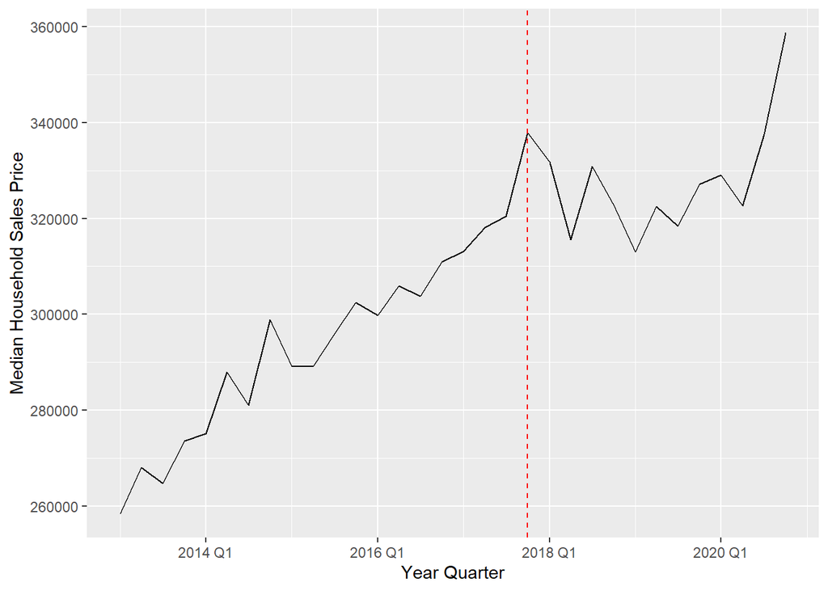

```r
# Get the prophet model
model <- glance(fit)

#change points
cp_df <- as.data.frame(model$changepoints[1])
cp <- yearquarter(as.Date(cp_df$changepoints))


threshold = 0.05 # Can adjust based on changepoint_prior_scale; should match

changepoints = fit %>%
glance() %>%
pull(changepoints) %>%
bind_rows() %>%
filter(abs(adjustment)>threshold) %>%
.$changepoints

# Plot changepoints
household_SP_decomp %>%
ggplot()+
geom_line(aes(date,value))+
# geom_vline(aes(xintercept=ymd('2000-01-01')))
geom_vline(xintercept=as.Date(changepoints),color='red',linetype='dashed') +
  ylab('Median Household Sales Price')+
    xlab('Year Quarter')
```

- The change point detected by the model is capturing the change / deflection in the trend before 2018.
- Post 2017 Q4, we see that the trend plateaus a bit
- There is a significant difference in the trend from 2020 Q2. This is not captured by the model.

**Model after tuning the Changepoint hyperparameters**

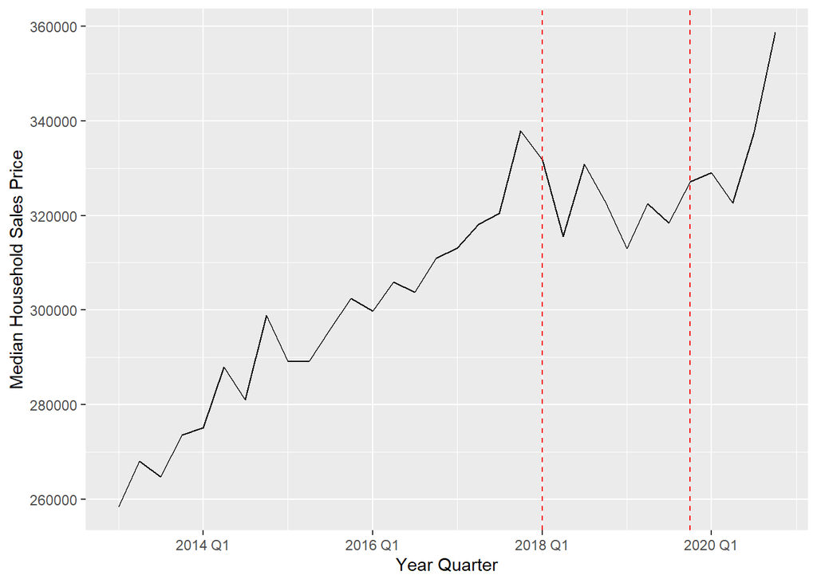

```r
fit_cp <- household_SP_med_train %>%
#filter(date<=ymd('2019-01-01')) %>%
    model(prophet = fable.prophet::prophet(value ~ growth(type = c("linear"), capacity = NULL, floor = NULL,
                                          changepoints = NULL, n_changepoints = 4, changepoint_range = 0.90,
                                          changepoint_prior_scale = 0.28))
          )

threshold = 0.28# Can adjust based on changepoint_prior_scale; should match

changepoints = fit_cp %>%
glance() %>%
pull(changepoints) %>%
bind_rows() %>%
filter(abs(adjustment)>threshold) %>%
.$changepoints

# Plot changepoints
household_SP_decomp %>%
ggplot()+
geom_line(aes(date,value))+
# geom_vline(aes(xintercept=ymd('2000-01-01')))
geom_vline(xintercept=as.Date(changepoints),color='red',linetype='dashed') +
  ylab('Median Household Sales Price')+
    xlab('Year Quarter')
```

The Changepoints above can be assumed as a better points capturing the significant changes in the trend

**Trend - Min Max Assessment** * The trend seems to follow a linear trend. It can be concluded that linear trend makes sense for the time series data * Based on business sense, since we have household sales price, this may not be a logistic trend series because it cannot potentially be capped to a higher saturation value. The lower (floor) value can also not be 0. As of now, we cannot estimate a potential floor value.

**Seasonality assessment**

From the time series decomposition we can see that the model has identified seasonality of 4 periods. However, we have assesd that is **fairly weak**

**Holiday assessment**

The time series data is not daily data and is present at quarterly intervals. Also, household sales price would not significantly change because holiday periods. Hence, we can move forward without accounting for holidays.

**Section 4**

#### Model Comparison and Validation

**Cross Validation**

**Cross Validation with different parameters**

```r
#Starting with 1 years of data and adding one year at a time
household_SP_med_cv_data<- household_SP_med_train |>
  stretch_tsibble(.init = 4, .step = 4)


# Cross Validation
household_SP_med_cv_forecast = household_SP_med_cv_data %>%
  model(naive = NAIVE(value ),
  arima = ARIMA(value~pdq(1,1,0)),
  prophet =  fable.prophet::prophet(value ~ growth(type = c("linear"), capacity = NULL, floor = NULL,
                                          changepoints = NULL, n_changepoints = 4, changepoint_range = 0.90,
                                          changepoint_prior_scale = 0.28))

  ) %>%
  forecast(h = 8)
```

**Model Comparison**

**RMSE based**

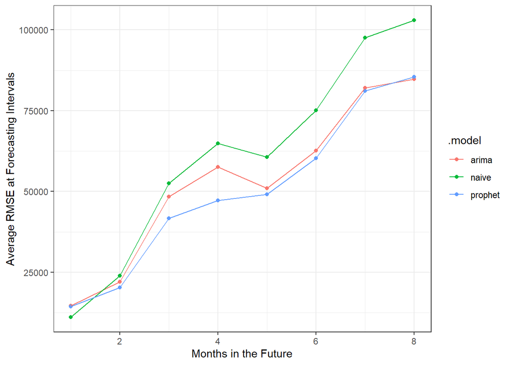

Out of the different models tried, Prophet has lower RMSE. Hence this can be chosen as the best model.

- For forecasting horizon, t+1 naive model is performing better than other models
- For forecasting horizon t+8, ARIMA is doing a similar job like Prohphet other models

**Final Assessment**

**Final Forecast of the best model**

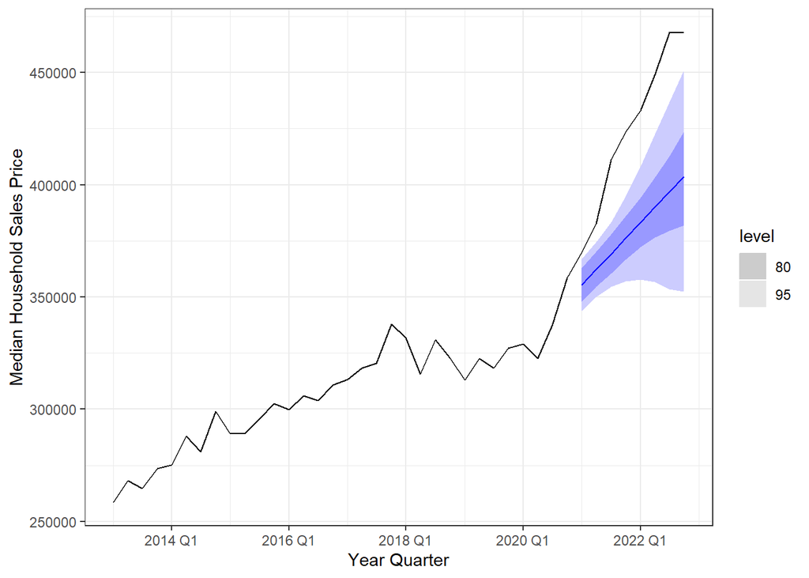

```r
household_SP_med_train |>
         model(linear_cp = fable.prophet::prophet(value ~ growth(type = c("linear"), capacity = NULL, floor = NULL,
                                          changepoints = NULL, n_changepoints = 4, changepoint_range = 0.90,
                                          changepoint_prior_scale = 0.28)
                                         )
               )%>%
  forecast(h=8) %>%
    autoplot(household_SP_med_train %>% bind_rows(household_SP_med_test)) +
    ylab('Median Household Sales Price')+
    xlab('Year Quarter')+
    theme_bw()
```